# Software Notes P - Feature Selection & Lasso Regression

Prepared for ISyE 4031  
Brandon Kang  
brandonkang@gatech.edu

```python
import pandas as pd
import numpy as np
import matplotlib.pyplot as plt
import seaborn as sns
from jupyterthemes import jtplot
from sklearn.feature_selection import SelectKBest, f_regression, mutual_info_regression, RFECV
from sklearn.model_selection import train_test_split, StratifiedKFold
from sklearn.linear_model import LinearRegression, LassoCV
from sklearn.preprocessing import StandardScaler
jtplot.style(theme='onedork')
```

## IMPORTANT NOTE

```python
dfHouses = pd.read_csv("houseData.csv", index_col=0)
features = list(dfHouses.columns.drop("price"))
X = dfHouses[features]
y = dfHouses["price"]
X_train, X_test, y_train, y_test = train_test_split(X, y, test_size=0.3, shuffle=True, random_state=42)
```

```python
X_train.head()
```

| id | bedrooms | bathrooms | sqft_living | sqft_lot | floors | waterfront | view | sqft_above | sqft_basement |
| --- | --- | --- | --- | --- | --- | --- | --- | --- | --- |
| 1836980160 | 4 | 2.50 | 2680 | 4499 | 2.0 | 0 | 0 | 2680 | 0 |
| 9221400335 | 4 | 1.75 | 2340 | 5080 | 1.0 | 0 | 0 | 1170 | 1170 |
| 6669020490 | 4 | 2.25 | 2190 | 9020 | 2.0 | 0 | 0 | 2190 | 0 |
| 2025079045 | 2 | 1.75 | 2260 | 280962 | 2.0 | 0 | 2 | 1890 | 370 |
| 1525069058 | 4 | 1.75 | 2110 | 265716 | 1.0 | 0 | 0 | 2110 | 0 |

**NOTE** Up until this point, I have not been splitting my datasets into training and testing since we have not reviewed some data preprocessing/cross validation concepts. Now that these software notes are up, we will be splitting our datasets into training/testing. For details in data preprocessing and cross validation, please refer to [here](https://brandonbks.github.io/static/concepts.pdf)!

```python
dfHouses.dtypes
```

```
price            float64
bedrooms           int64
bathrooms        float64
sqft_living        int64
sqft_lot           int64
floors           float64
waterfront         int64
view               int64
sqft_above         int64
sqft_basement      int64
dtype: object
```

## Correlation Checks

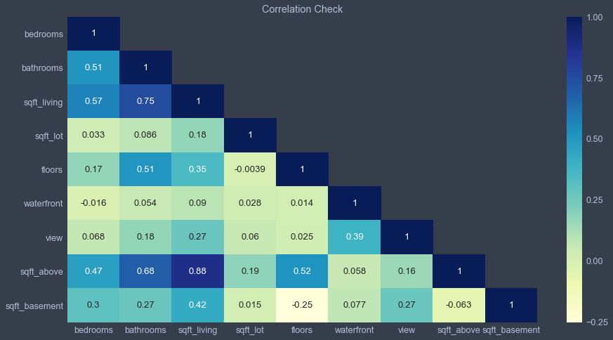

```python
corr = X_train.corr()
mask = np.zeros_like(corr)
mask[np.triu_indices_from(mask)] = True
np.fill_diagonal(mask, 0)

fig, ax = plt.subplots(figsize=(15, 8))
ax = sns.heatmap(corr, annot=True, mask=mask, cmap="YlGnBu")
plt.title("Correlation Check")
```

It's important to check pairwise correlations between features (as well as VIF) when running your models. We'll go into VIF in a later software notes, but we need to check correlations and VIF values in order to assess multicollinearity. As mentioned in the previous software notes, models with high multicollinearity may result in biased results, and in some cases, the matrix for solving for optimal parameters may be invertible. Any pairwise correlations above 0.8 or so may be worth noting, and if you see unusually high pairwise correlations, it may be a good idea to combine the features or remove one. Ridge regression or using PCA may also be an alternative if your model is suffering from multicollinearity.  
*Note:* Why did I include only one triangular region?

## F-Test

```python
selector = SelectKBest(f_regression, k="all").fit(X_train, y_train) #You can modify the k parameter to retain the k best
pVal = selector.pvalues_ #obtain p-value from F statistic
mapPVal = list(zip(pVal, X.columns)) #map column to its p-value
dfPVal = pd.Series({i[1]: i[0] for i in mapPVal}).reset_index().rename({"index": "feature", 0: "p-value"}, axis=1)
```

```python
dfPVal = dfPVal.sort_values("p-value", ascending=True)
dfPVal['rank'] = np.arange(len(dfPVal))+1
dfPVal
```

|  | feature | p-value | rank |
| --- | --- | --- | --- |
| 0 | bedrooms | 0.000000e+00 | 1 |
| 1 | bathrooms | 0.000000e+00 | 2 |
| 2 | sqft_living | 0.000000e+00 | 3 |
| 6 | view | 0.000000e+00 | 4 |
| 7 | sqft_above | 0.000000e+00 | 5 |
| 8 | sqft_basement | 0.000000e+00 | 6 |
| 4 | floors | 4.303223e-220 | 7 |
| 5 | waterfront | 6.013830e-205 | 8 |
| 3 | sqft_lot | 1.332256e-29 | 9 |

F-Test in Sci-Kit Learn's feature selection module essentially does a hypothesis testing against your ground truth, y, and one feature at a time. For example, it will run price~bedrooms, obtain the respective p-value and F score in order to determine if the relationship is significant. However, this particular method can be somewhat problematic, as it only captures *linear* dependencies. There may exist a nonlinear relationship, so this method will not be able to capture that.  
I wrapped this function with SelectKBest which will essentially select the "K" best features based on their scores. In this software note, I just returned all for your viewing, but you can adjust this parameter as you like.

## Mutual Information

```python
dfTotalScores = pd.Series(X.columns).reset_index().rename({0: "feature"}, axis=1)
dfTotalScores = dfTotalScores.drop("index", axis=1)
for n in range(2, 6):
    scores = mutual_info_regression(X_train, y_train, n_neighbors=n)
    mapScores = list(zip(scores, X.columns))
    dfScores = pd.Series({i[1]: i[0] for i in mapScores}).reset_index()\
                                                        .rename({"index": "feature", 0: "scores"+str(n)}, axis=1)
    dfTotalScores = dfTotalScores.merge(dfScores, on="feature")
dfTotalScores = dfTotalScores.set_index("feature")
dfTotalScores["average"] = dfTotalScores.mean(axis = 1)
```

```python
dfTotalScores = dfTotalScores.sort_values("average", ascending=False)
dfTotalScores['rank'] = np.arange(len(dfTotalScores))+1
dfTotalScores
```

| feature | scores2 | scores3 | scores4 | scores5 | average | rank |
| --- | --- | --- | --- | --- | --- | --- |
| sqft_living | 0.362136 | 0.348047 | 0.347160 | 0.346693 | 0.351009 | 1 |
| sqft_above | 0.269906 | 0.254001 | 0.251775 | 0.252682 | 0.257091 | 2 |
| bathrooms | 0.218570 | 0.210376 | 0.206259 | 0.202556 | 0.209440 | 3 |
| bedrooms | 0.081140 | 0.079222 | 0.078877 | 0.071361 | 0.077650 | 4 |
| floors | 0.085494 | 0.077950 | 0.066939 | 0.075751 | 0.076534 | 5 |
| sqft_basement | 0.067540 | 0.068426 | 0.065449 | 0.068231 | 0.067412 | 6 |
| sqft_lot | 0.072042 | 0.067613 | 0.062576 | 0.066230 | 0.067115 | 7 |
| view | 0.048218 | 0.048426 | 0.050768 | 0.059025 | 0.051610 | 8 |
| waterfront | 0.009776 | 0.007537 | 0.012004 | 0.015210 | 0.011132 | 9 |

Mutual information essentially measures the dependence of a feature to the actual ground truth, y. There are 3 possible scenarios:

1. The feature and response are completely independent. In other words, knowing a feature will provide you no information about y. Therefore, mutual information is 0.
2. The feature and response are related with no source of error or randomness. For example, let's say y is the sale price, and x is the amount of candy bars you purchase. Obviously, the sale price is set at a fixed price, so you will always know the sale price given the amount of candy bars you purchase. In this case, mutual information is 1.
3. The in between. Knowing x will allow you to gain some information about the response, y. In this case, mutual information is in between 0 and 1.

The power of mutual information comes from now being able to capture nonlinear dependencies. Click [here](https://scikit-learn.org/stable/auto_examples/feature_selection/plot_f_test_vs_mi.html#sphx-glr-auto-examples-feature-selection-plot-f-test-vs-mi-py) for detailed comparisons between F-Test and mutual information and [here](https://scikit-learn.org/stable/modules/generated/sklearn.feature_selection.mutual_info_regression.html#sklearn.feature_selection.mutual_info_regression) for documentation.

## Recursive Feature Elimination

```python
mlr = LinearRegression()
rfecv = RFECV(estimator=mlr, step=1, cv=StratifiedKFold(2))
rfecv.fit(X_train, y_train)
```

```
RFECV(cv=StratifiedKFold(n_splits=2, random_state=None, shuffle=False),
      estimator=LinearRegression(copy_X=True, fit_intercept=True, n_jobs=None,
                                 normalize=False),
      min_features_to_select=1, n_jobs=None, scoring=None, step=1, verbose=0)
```

```python
X_train = X_train[X_train.columns[rfecv.support_]]
X_train.head()
```

| id | bedrooms | bathrooms | sqft_living | sqft_lot | floors | waterfront | view | sqft_above | sqft_basement |
| --- | --- | --- | --- | --- | --- | --- | --- | --- | --- |
| 1836980160 | 4 | 2.50 | 2680 | 4499 | 2.0 | 0 | 0 | 2680 | 0 |
| 9221400335 | 4 | 1.75 | 2340 | 5080 | 1.0 | 0 | 0 | 1170 | 1170 |
| 6669020490 | 4 | 2.25 | 2190 | 9020 | 2.0 | 0 | 0 | 2190 | 0 |
| 2025079045 | 2 | 1.75 | 2260 | 280962 | 2.0 | 0 | 2 | 1890 | 370 |
| 1525069058 | 4 | 1.75 | 2110 | 265716 | 1.0 | 0 | 0 | 2110 | 0 |

Recursive feature elimination works in a similar fashion to backwards elimination, but not entirely. The aim of this method is to select features by recursively selecting smaller and smaller sets of features. In the first pass, the estimator, in this case Linear Regression model, runs with all of the features. It then analyzes the importance of each feature by its coef_ attribute, and features are pruned (removed) until the optimal number of features is met through cross validation. In our example above, none of the features are removed, which makes sense since we have a small number of features, and they're all highly significant as we saw in the F-test screening.

## Lasso Regression

$ \newcommand\norm[1]{\left\lVert#1\right\rVert} $ Recall the loss function and optimization problem for multiple linear regression. $$ \begin{align} \min_\hat{\beta} \norm{y-X\hat{\beta}}_2^2 \end{align} $$ Linear regression, like any other model, can be susceptible to a pitfall known as *overfitting.* This concept is described in much more detail in additional software notes [here](https://brandonbks.github.io/static/concepts.pdf). In linear regression, overfitting can occur where the $\hat{\beta}$'s can become extremely large, causing our model to have high variance. One cause of overfitting is having too large of a feature space relative to the number of data points (curse of dimensionality), which is also described in the software notes linked, and we will attempt to combat this with Lasso Regression.

[figure not shown]

Pay attention to the green dots, which is what the regression model was trained on. The red line plots the regression equation using just ordinary least squares, and you can see that the regression equation is highly overfitting and does not generalize well with they yellow (validation) points. In other words, if this regression model was used to predict future observations, it would perform terribly, and you can visualize this with the yellow points. The other lines, using Lasso Regression, perform much better against the validation points, as you can see it fits the yellow points far better.  
In this case you can see that small perturbations in input values can cause dramatic changes in the output value, which means that the solution is not stable (i.e high variance). You can see this in the red line above -- if you move slightly in one direction, especially from 0.8 to 0.9, there can be a dramatic change in the predicted value. Similarly, when you have features that are highly correlated, linear regression models will tend to overfit.  
In order to avoid this case, there are two altnerative methods: Ridge and Lasso Regression. However, we will only focus on Lasso Regression for these software notes, as it is more related to variable selection, whereas Ridge Regression is more suited for dealing with multicollinearity.

Let's first detail the constrained optimization problem for Lasso Regression: $$ \begin{align} \min_\hat{\beta}& \norm{y-X\hat{\beta}}_2^2 \\ s.t. & \norm{\hat{\beta}}_1 \leq s \\ \end{align} $$

We can use Lagrangian multipliers to incorporate the constraint into the objective function.

$$ \begin{align} \min_\hat{\beta} \norm{y-X\hat{\beta}}_2^2 + \lambda \sum_{k=1}^K |\hat{\beta}_k| \end{align} $$

Note that the first term in the objective function is to minimize the sum of square errors, which is identical to the term in the objective function for multiple linear regression. However, in order to control the size of the coefficients, we add a penalization term on the coefficients. Note that this is equivalent to the L1-norm. Refer to software notes 4 for the definition of a norm [here](https://brandonbks.github.io/static/sn4.html). Therefore, the objective function will ensure that the coefficients will not become too large and reduce the variance of our model since they are penalized in the objective function, but the L1-norm also does something interesting with the coefficients.

Due to the geometry of the L1-norm, Lasso Regression shrinks some of the coefficients down to 0. Note that if the beta coefficient is zero, this means that the particular feature (or interaction of features) will not be significant and does not affect the output. Let's visualize the geometry of the L1-norm where we have 2 $\hat{\beta}$'s.

[figure not shown]

We can visualize from above the OLS estimate if we just minimized the sum of squared errors as $\hat{\beta}$. Due to the additional constraint of the $\beta$ terms, the feasible set of solutions lie within the diamond region. The contours above represent the loss function, and you should note that for the optimal case (i.e when the contour first hits the feasible region), the contour will only hit at one of the verticies of the diamond. From this geometric viewpoint, you should be able to see that one of the $\beta$'s is forced to 0 (namely, $\beta_1$), whereas $\beta_2$ is non-zero. Because of the geometric nature of the L1-norm, Lasso Regression can also be a variable selection method. Since it forces some $\beta$'s to zero, you can find which features are not significant and do not affect the overall model while also minimizing overfitting compared to OLS.

Few notes:

1. The size of $\lambda$ controls model complexity. The larger the value of $\lambda$, the more it restricts the parameters (since it penalizes the objective function more). Choose $\lambda$ through cross validation.
2. Do not use Lasso Regression when your model is suffering from multicollinearity. Ridge Regression should be used instead.

```python
scaler = StandardScaler()
X_train_standard = scaler.fit_transform(X_train)
reg = LassoCV(cv = 5).fit(X_train_standard, y_train)
```

```python
reg.alpha_
```

```
778.6886173503407
```

```python
for ind, col in enumerate(X_train.columns):
    print(col, " for Beta_", ind+1, " = ", reg.coef_[ind])
print("intercept is", reg.intercept_)
```

```
bedrooms  for Beta_ 1  =  -40541.01039716413
bathrooms  for Beta_ 2  =  5519.98245096863
sqft_living  for Beta_ 3  =  255061.66301448777
sqft_lot  for Beta_ 4  =  -14552.196182652677
floors  for Beta_ 5  =  4144.11955991439
waterfront  for Beta_ 6  =  42292.440671644916
view  for Beta_ 7  =  56666.25645653237
sqft_above  for Beta_ 8  =  0.0
sqft_basement  for Beta_ 9  =  0.0
intercept is 537729.2636658074
```

From the above equation, we can see that sqft_above and sqft_basement $\beta$ coefficients are 0, so they do not affect the output. One important note is that we need to standardize our data when using Lasso regression. Note that the constraint in the original optimization function is dependent on the magnitude of each variable, so it's necessary to standardize the variables.

## Other Methods...

There are definitely other popular methods in reducing the dimensionality of a dataset. Although we won't go into them here, you can run PCA (principal components analysis), which essentially attempts to find directions of maximum variance by taking linear combinations of features and reducing the dimensionality of the dataset. This is particularly good when there are some correlations between features.  
Another popular method is to run some tree-based regression model (such as Random Forest or Gradient Boosting) on your dataset and output feature importance values. These feature importance values are derived from the amount of times a feature was split on when creating the tree. If a feature has very low feature importance, it may be a good idea to remove the feature.  
Although these two methods are popular and powerful, we won't go over them here. I will delve into them deeper in a separate software notes dedicated to more Machine Learning methods!